# Loyalty program in retail.

# Table of Contents

## Общее описание проекта и исходные данные.

Исследование по запросу менеджера отдела маркетинга.

Исследовали продажи сети магазинов и программу лояльности (ПЛ):

- суммы чеков;
- категрии покупателей;
- динамику продаж и пр.

Исследование выполнено на основе логов продаж, полученных с касс магазинов.

Исследование выполнено в период: март 2017 года.

```python
import warnings
warnings.filterwarnings(action='ignore')
```

```python
import pandas as pd
import seaborn as sns
import numpy as np
import matplotlib.pyplot as plt
from matplotlib.ticker import MultipleLocator
import datetime as dt
from datetime import date, time, datetime, timedelta
from scipy import stats as st
```

## Проверка и предобработка данных.

### Данные о продажах.

```python
sales.head()
```

|  | purchaseid | item_ID | Quantity | purchasedate | CustomerID | ShopID | loyalty_program |
| --- | --- | --- | --- | --- | --- | --- | --- |
| 0 | 538280 | 21873 | 11 | 2016-12-10 12:50:00 | 18427.0 | Shop 0 | 0.0 |
| 1 | 538862 | 22195 | 0 | 2016-12-14 14:11:00 | 22389.0 | Shop 0 | 1.0 |
| 2 | 538855 | 21239 | 7 | 2016-12-14 13:50:00 | 22182.0 | Shop 0 | 1.0 |
| 3 | 543543 | 22271 | 0 | 2017-02-09 15:33:00 | 23522.0 | Shop 0 | 1.0 |
| 4 | 543812 | 79321 | 0 | 2017-02-13 14:40:00 | 23151.0 | Shop 0 | 1.0 |

```python
sales.columns = ['purchase_id', 'item_id', 'quantity', 'date_time', 'customer_id', 'shop_id', 'loyalty']
```

```python
sales.head()
```

|  | purchase_id | item_id | quantity | date_time | customer_id | shop_id | loyalty |
| --- | --- | --- | --- | --- | --- | --- | --- |
| 0 | 538280 | 21873 | 11 | 2016-12-10 12:50:00 | 18427.0 | Shop 0 | 0.0 |
| 1 | 538862 | 22195 | 0 | 2016-12-14 14:11:00 | 22389.0 | Shop 0 | 1.0 |
| 2 | 538855 | 21239 | 7 | 2016-12-14 13:50:00 | 22182.0 | Shop 0 | 1.0 |
| 3 | 543543 | 22271 | 0 | 2017-02-09 15:33:00 | 23522.0 | Shop 0 | 1.0 |
| 4 | 543812 | 79321 | 0 | 2017-02-13 14:40:00 | 23151.0 | Shop 0 | 1.0 |

**Типы данных.**

```python
sales.info()
```

```
<class 'pandas.core.frame.DataFrame'>
RangeIndex: 105335 entries, 0 to 105334
Data columns (total 7 columns):
 #   Column       Non-Null Count   Dtype
---  ------       --------------   -----
 0   purchase_id  105335 non-null  object
 1   item_id      105335 non-null  object
 2   quantity     105335 non-null  int64
 3   date_time    105335 non-null  object
 4   customer_id  69125 non-null   float64
 5   shop_id      105335 non-null  object
 6   loyalty      105335 non-null  float64
dtypes: float64(2), int64(1), object(4)
memory usage: 5.6+ MB
```

```python
sales['date_time'] = pd.to_datetime(sales['date_time'], format='%Y-%m-%d %H:%M:%S')
```

```python
sales['loyalty'] = sales['loyalty'].astype('bool')
```

**Обработали типы:**

- `purchase_id` -- не стали менять: категориальная переменная, может иметь разное наполнение (цифры, буквы и пр.);
- `item_id` -- не стали менять: категориальная переменная, может иметь разное наполнение (цифры, буквы и пр.);
- `quantity` -- корректный формат;
- `date_time` -- на формат даты-времени;
- `customer_id` -- не стали менять: категориальная переменная, может иметь разное наполнение (цифры, буквы и пр.);
- `shop_id` -- не стали менять: категориальная переменная, может иметь разное наполнение (цифры, буквы и пр.);
- `loyalty` -- поменяли на bool.

**Дубликаты.**

```python
sales.duplicated().sum()
```

```
1033
```

```python
print('Доля дубликатов: {:.2%}.'.format(sales.duplicated().sum() / sales.shape[0]))
```

```
Доля дубликатов: 0.98%.
```

Удалили явные дубликаты: корректно работающая касса не может создавать 2 одинаковые транзакции в одно и то же время с точностью до секунд.

```python
sales = sales.drop_duplicates()
sales.duplicated().sum()
```

```
0
```

**Пропуски.**

```python
sales.isna().mean().round(4).to_frame().sort_values(by=0).style.format('{:.2%}').background_gradient(cmap='Blues')
```

|  | 0 |
| --- | --- |
| purchase_id | 0.00% |
| item_id | 0.00% |
| quantity | 0.00% |
| date_time | 0.00% |
| shop_id | 0.00% |
| loyalty | 0.00% |
| customer_id | 34.66% |

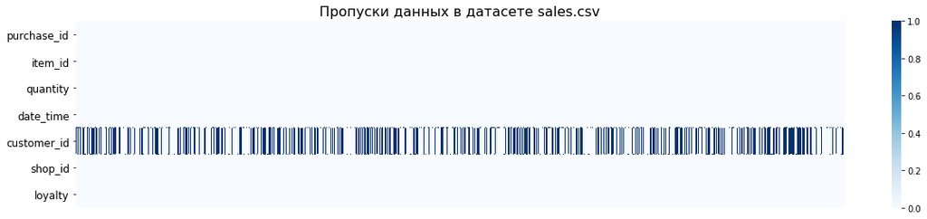

```python
plt.figure(figsize=(20,4))
sns.heatmap(sales.isna().transpose(), cmap='Blues', xticklabels=False)
plt.tick_params(labelsize=12)
plt.title('Пропуски данных в датасете sales.csv', fontsize=16)
plt.show()
```

```python
#функция группирует пропусски по отдельным переменным
def nan(data):
    nan_values = data.isna().sum()/data.shape[0]
    return nan_values
```

```python
sales.groupby('shop_id').agg(nan).sort_values(by='customer_id', ascending=False).head()
```

| shop_id | purchase_id | item_id | quantity | date_time | customer_id | loyalty |
| --- | --- | --- | --- | --- | --- | --- |
| Shop 23 | 0.0 | 0.0 | 0 | 0.0 | 1.000000 | False |
| Shop 25 | 0.0 | 0.0 | 0 | 0.0 | 1.000000 | False |
| Shop 21 | 0.0 | 0.0 | 0 | 0.0 | 0.437500 | False |
| Shop 0 | 0.0 | 0.0 | 0 | 0.0 | 0.373062 | False |
| Shop 6 | 0.0 | 0.0 | 0 | 0.0 | 0.123301 | False |

```python
sales.groupby('loyalty').agg(nan).sort_values(by='customer_id', ascending=False).head()
```

| loyalty | purchase_id | item_id | quantity | date_time | customer_id | shop_id |
| --- | --- | --- | --- | --- | --- | --- |
| False | 0.0 | 0.0 | 0 | 0.0 | 0.446878 | 0.0 |
| True | 0.0 | 0.0 | 0 | 0.0 | 0.000000 | 0.0 |

```python
sales[sales['customer_id'].isna()]['quantity'].sum()
```

```
64348
```

**Наблюдаем:**

- пропуски только в столбце `customer_id`;
- причины пропусков неизвестны; согласно условий задачи, "все покупатели могут получить доступ в магазин с использованием персональных карт"; иными словами, должны логироваться данные обо всех id покупателей, покупателя без id не должно быть;
- вероятнее всего, пропуски -- результат технической ошибки;
- "генераторами" пропусков являются несколько магазинов;
- все пропуски -- у не-участников ПЛ;
- при этом пропуски не препятствуют дальнейшему анализу, кроме когортного анализа;
- на этом этапе было принято решение пропуски не удалять.

**Аномалии в категориальных переменных.**

```python
sales['purchase_id'].nunique()
```

```
4894
```

```python
sales['item_id'].nunique()
```

```
3159
```

```python
sales['customer_id'].nunique()
```

```
1749
```

```python
sales['shop_id'].unique()
```

```
array(['Shop 0', 'Shop 1', 'Shop 4', 'Shop 6', 'Shop 2', 'Shop 11',
       'Shop 3', 'Shop 5', 'Shop 7', 'Shop 12', 'Shop 8', 'Shop 27',
       'Shop 10', 'Shop 20', 'Shop 19', 'Shop 25', 'Shop 14', 'Shop 21',
       'Shop 18', 'Shop 9', 'Shop 16', 'Shop 28', 'Shop 29', 'Shop 17',
       'Shop 22', 'Shop 13', 'Shop 26', 'Shop 24', 'Shop 15', 'Shop 23',
       'Shop 30'], dtype=object)
```

```python
sales['loyalty'].unique()
```

```
array([False,  True])
```

Данные в этой части выглядят корректно.

**Пересекаются ли множества участников ПЛ, и не-участников ПЛ?**

```python
customers_loyal = sales.query('loyalty == 1')['customer_id'].unique()
customers_usual = sales.query('loyalty == 0')['customer_id'].unique()
```

```python
list(set(customers_loyal) & set(customers_usual))
```

```
[]
```

Множества участников ПЛ и не-участников ПЛ не пересекаются.

**Аномалии в непрерывных переменных.**

```python
sales['quantity'].describe()
```

```
count    104302.000000
mean          7.883003
std         329.565540
min      -74216.000000
25%           0.000000
50%           2.000000
75%           7.000000
max       74214.000000
Name: quantity, dtype: float64
```

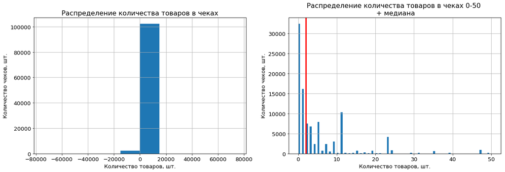

```python
plt.figure(figsize=(20, 6))

ax1 = plt.subplot(1, 2, 1)
ax1 = sales['quantity'].hist(bins=10)
ax1.set_title('Распределение количества товаров в чеках', fontsize=16)
ax1.tick_params(labelsize=13)
ax1.set_xlabel('Количество товаров, шт.', fontsize=13)
ax1.set_ylabel('Количество чеков, шт.', fontsize=13)

ax2 = plt.subplot(1, 2, 2)
ax2 = sales['quantity'].hist(range=(0, 50), bins=100)
x2 = sales['quantity'].median()
ax2.axvline(x=x2, color='#FF0000', lw=3, linestyle='-')
ax2.set_title('Распределение количества товаров в чеках 0-50 \n + медиана', fontsize=16)
ax2.tick_params(labelsize=13)
ax2.set_xlabel('Количество товаров, шт.', fontsize=13)
ax2.set_ylabel('Количество чеков, шт.', fontsize=13)

plt.show()
```

```python
sales.query('quantity == 0')['quantity'].count()
```

```
32362
```

```python
sales.query('quantity < 0')['quantity'].count()
```

```
2076
```

```python
sales.query('quantity > 1000')['quantity'].count()
```

```
34
```

```python
sales.query('quantity <= 0').groupby('shop_id').agg({'item_id': 'count'}).sort_values(by='item_id', ascending=False)
```

| shop_id | item_id |
| --- | --- |
| Shop 0 | 33831 |
| Shop 4 | 201 |
| Shop 1 | 105 |
| Shop 6 | 86 |
| Shop 8 | 57 |
| Shop 14 | 41 |
| Shop 18 | 41 |
| Shop 12 | 16 |
| Shop 10 | 15 |
| Shop 3 | 11 |
| Shop 11 | 10 |
| Shop 2 | 5 |
| Shop 16 | 4 |
| Shop 19 | 3 |
| Shop 7 | 3 |
| Shop 20 | 3 |
| Shop 21 | 2 |
| Shop 22 | 2 |
| Shop 23 | 1 |
| Shop 5 | 1 |

```python
sales_clean = sales.query('0 < quantity < 1000').copy()
```

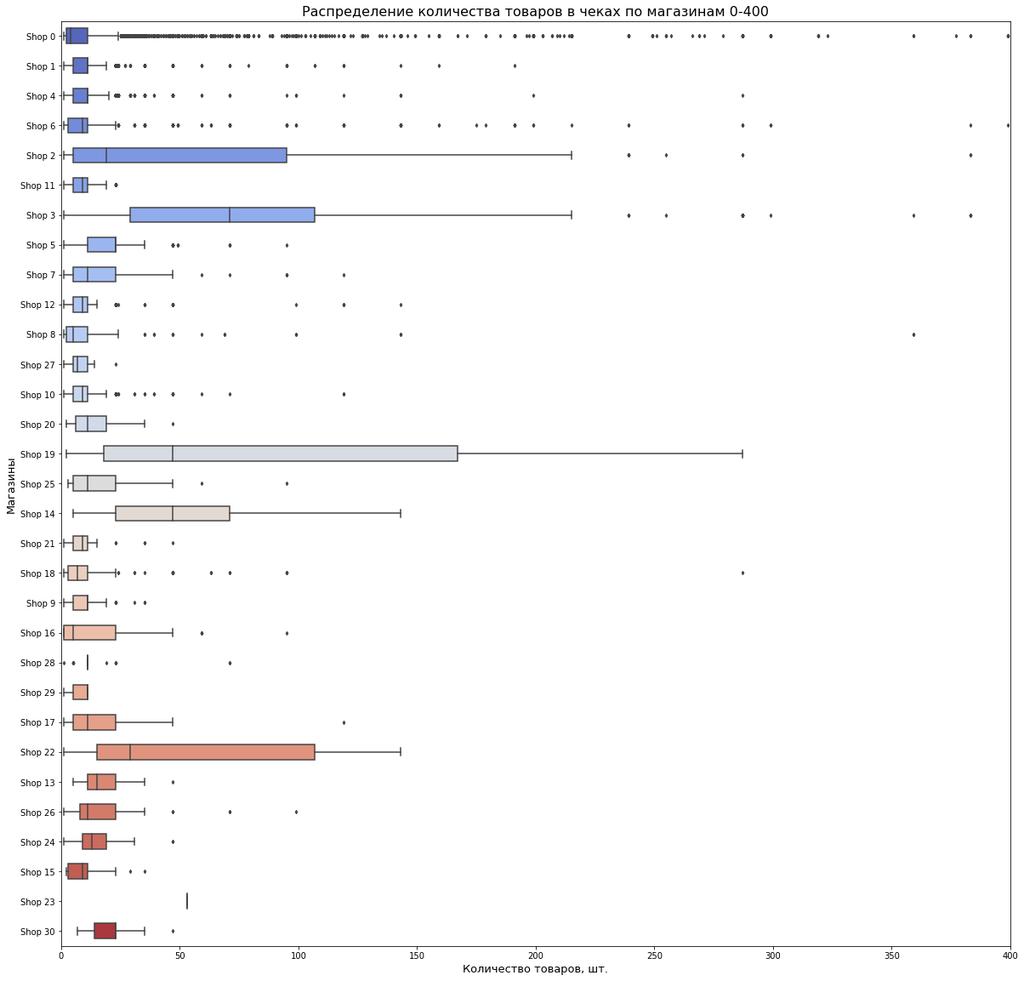

```python
plt.figure(figsize=(20, 20))
sns.boxplot(y='shop_id', x='quantity', data=sales_clean, orient='h', width=0.5, fliersize=3, palette='coolwarm')
plt.title('Распределение количества товаров в чеках по магазинам 0-400', fontsize=16)
plt.xlabel('Количество товаров, шт.', fontsize=13)
plt.ylabel('Магазины', fontsize=13)
plt.xlim(0, 400)
plt.show()
```

**Наблюдаем:**

- имеем данные о нулевых и отрицательных количествах товаров;
- данные с отрицательным количеством в основном по магазину Shop 0;
- также есть незначительное количество покупок с количеством товаров более 1000 единиц;
- магазины сильно различаются по количеству продаваемых товаров;
- для дальнейшего исследования оставили только данные с количеством товаров в одной позиции от 0 до 1000 единиц.

```python
print('Располагаем данными за период: {0} -- {1}.'.format(sales_clean['date_time'].min(), sales_clean['date_time'].max()))
```

```
Располагаем данными за период: 2016-12-01 08:26:00 -- 2017-02-28 17:01:00.
```

Отсортировали по времени покупки, чтобы данные были в хронологическом порядке.

```python
sales_clean = sales_clean.sort_values(by = 'date_time').reset_index(drop = True)
```

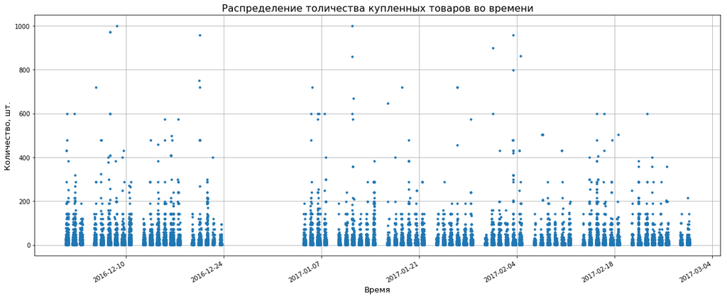

```python
sales_clean.plot(x='date_time', y='quantity', style='.', grid=True, figsize=(20, 8), legend=False)
plt.title('Распределение толичества купленных товаров во времени', fontsize=16)
plt.xlabel('Время', fontsize=13)
plt.ylabel('Количество, шт.', fontsize=13)
plt.show()
```

**Наблюдаем:**

- располагаем данными за период: 2016-12-01 08:26:00 -- 2017-02-28 17:01:00;
- данные распределены равномерно;
- товары продавались 6 дней в неделю, 1 день не продавались;
- товары не продавались в начале года (примерно соответствует новогодним каникулам;
- режим работы магазинов достоверно неизвестен; вероятно, разрыв в данных – следствие каникул торговой сети.

### Данные о товарах.

```python
prod.head()
```

|  | productID | price_per_one |
| --- | --- | --- |
| 0 | 85123A | 2.55 |
| 1 | 71053 | 3.39 |
| 2 | 84406B | 2.75 |
| 3 | 84029G | 3.39 |
| 4 | 84029E | 3.39 |

```python
prod.columns = ['item_id', 'price']
```

**Типы данных.**

```python
prod.info()
```

```
<class 'pandas.core.frame.DataFrame'>
RangeIndex: 9969 entries, 0 to 9968
Data columns (total 2 columns):
 #   Column   Non-Null Count  Dtype
---  ------   --------------  -----
 0   item_id  9969 non-null   object
 1   price    9969 non-null   float64
dtypes: float64(1), object(1)
memory usage: 155.9+ KB
```

**Обработали типы:**

- `item_id` -- не стали менять: категориальная переменная, может иметь разное наполнение (цифры, буквы и пр.);
- `price` -- корректный формат.

**Дубликаты.**

```python
prod.duplicated().sum()
```

```
0
```

**Пропуски.**

```python
prod.isna().sum()
```

```
item_id    0
price      0
dtype: int64
```

**Аномалии в данных.**

```python
prod['item_id'].nunique()
```

```
3159
```

```python
print('В базе sales данные о {0} товарах. В базе prod данные о {1} товарах.'.\
      format(sales_clean['item_id'].nunique(), prod['item_id'].nunique()))
```

```
В базе sales данные о 2773 товарах. В базе prod данные о 3159 товарах.
```

```python
prod['item_id'].value_counts()
```

```
DOT       174
M          59
S          29
POST       15
D          13
         ...
90026D      1
90140       1
90188       1
90141D      1
46776E      1
Name: item_id, Length: 3159, dtype: int64
```

```python
prod['price'].describe()
```

```
count     9969.000000
mean        19.503697
std        330.880754
min          0.000000
25%          1.250000
50%          2.550000
75%          5.510000
max      16888.020000
Name: price, dtype: float64
```

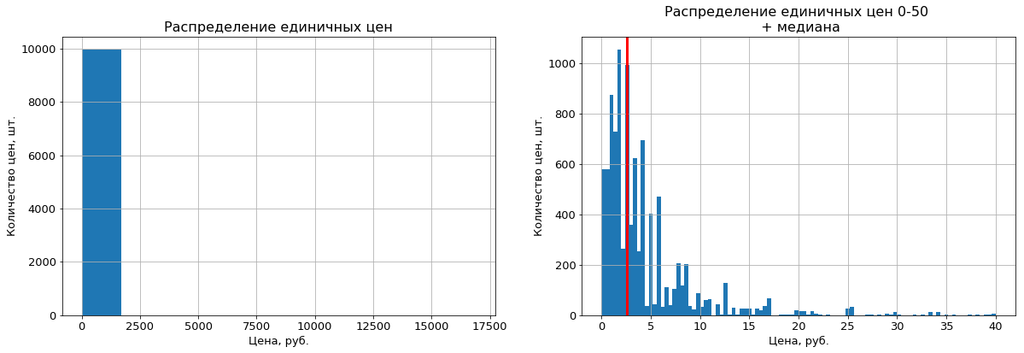

```python
plt.figure(figsize=(20, 6))

ax1 = plt.subplot(1, 2, 1)
ax1 = prod['price'].hist()
ax1.set_title('Распределение единичных цен', fontsize=16)
ax1.tick_params(labelsize=13)
ax1.set_xlabel('Цена, руб.', fontsize=13)
ax1.set_ylabel('Количество цен, шт.', fontsize=13)


ax2 = plt.subplot(1, 2, 2)
ax2 = prod['price'].hist(range=(0, 40), bins=100)
x2 = prod['price'].median()
ax2.axvline(x=x2, color='#FF0000', lw=3, linestyle='-')
ax2.set_title('Распределение единичных цен 0-50 \n + медиана', fontsize=16)
ax2.tick_params(labelsize=13)
ax2.set_xlabel('Цена, руб.', fontsize=13)
ax2.set_ylabel('Количество цен, шт.', fontsize=13)

plt.show()
```

```python
prod.query('price == 0')['price'].count()
```

```
382
```

```python
prices = (prod.groupby('item_id', as_index=False).agg(counts=('price', 'nunique'),
                                           max_price=('price', 'max'),
                                           min_price=('price', 'min'))
         )
prices['dif_price'] = prices['max_price'] - prices['min_price']
prices.sort_values(by='dif_price', ascending=False).head(10)
```

|  | item_id | counts | max_price | min_price | dif_price |
| --- | --- | --- | --- | --- | --- |
| 3136 | AMAZONFEE | 9 | 16888.02 | 1.00 | 16887.02 |
| 3151 | M | 59 | 1715.85 | 0.19 | 1715.66 |
| 3137 | BANK CHARGES | 8 | 1050.15 | 15.00 | 1035.15 |
| 3150 | DOT | 174 | 950.99 | 2.51 | 948.48 |
| 3139 | D | 13 | 281.00 | 5.76 | 275.24 |
| 1507 | 22655 | 3 | 295.00 | 125.00 | 170.00 |
| 3138 | C2 | 3 | 150.00 | 15.00 | 135.00 |
| 3153 | S | 29 | 128.56 | 2.80 | 125.76 |
| 1678 | 22833 | 4 | 100.00 | 0.00 | 100.00 |
| 1617 | 22769 | 4 | 51.02 | 0.00 | 51.02 |

**Наблюдаем:**

- в базе данные о 3159 товарах; не все эти товары продавались;
- большиство товаров продаётся по невысокой цене до 5 руб./ед.;
- располагаем разрозненными данными о ценах товаров;
- на некоторые позиции товаров имеем много значений цен;
- сами значения по разным товарам различаются в разы или на несколько порядков;
- присутствуют нулевые цены;
- не имеем достоверных данных о причинах различий цен, поэтому в качестве цены единицы взяли медианное значение цены;
- нулевые цены оставили: возможно, это какие-либо подарки, бонусы покупателям.

```python
prod_clean = (prod.groupby('item_id', as_index=False).agg(price=('price', 'median')).
              reset_index(drop=True)
             )
prod_clean['price'] = round(prod_clean['price'], 2)
```

```python
prod_clean.info()
```

```
<class 'pandas.core.frame.DataFrame'>
RangeIndex: 3159 entries, 0 to 3158
Data columns (total 2 columns):
 #   Column   Non-Null Count  Dtype
---  ------   --------------  -----
 0   item_id  3159 non-null   object
 1   price    3159 non-null   float64
dtypes: float64(1), object(1)
memory usage: 49.5+ KB
```

```python
prod_clean.query('price == 0')['price'].count()
```

```
57
```

**Промежуточные выводы:**

- имеются пропуски в столбце `customer_id`;
- причины пропусков неизвестны; согласно условий задачи, "все покупатели могут получить доступ в магазин с использованием персональных карт"; иными словами, должны логироваться данные обо всех id покупателей, покупателя без id не должно быть;
- вероятнее всего, пропуски -- результат технической ошибки;
- "генераторами" пропусков являются несколько магазинов;
- все пропуски -- у не-участников ПЛ;
- при этом пропуски не препятствуют дальнейшему анализу, кроме когортного анализа;
- на этом этапе было принято решение пропуски не удалять;
- имеем данные о нулевых и отрицательных количествах товаров;
- данные с отрицательным количеством в основном по магазину Shop 0;
- также есть незначительное количество покупок с количеством товаров более 1000 единиц;
- магазины сильно различаются по количеству продаваемых товаров;
- для дальнейшего исследования оставили только данные с количеством товаров в одной позиции от 0 до 1000 единиц;
- располагаем данными за период: 2016-12-01 08:26:00 -- 2017-02-28 17:01:00;
- данные распределены равномерно;
- товары продавались 6 дней в неделю, 1 день не продавались;
- товары не продавались в начале года (примерно соответствует новогодним каникулам;
- режим работы магазинов достоверно неизвестен; вероятно, разрыв в данных – следствие каникул торговой сети;
- в базе данные о 3159 товарах; не все эти товары продавались;
- располагаем разрозненными данными о ценах товаров;
- на некоторые позиции товаров имеем много значений цен;
- сами значения по разным товарам различаются в разы или на несколько порядков;
- присутствуют нулевые цены;
- не имеем достоверных данных о причинах различий цен, поэтому в качестве цены единицы взяли медианное значение цены;
- нулевые цены оставили: возможно, это какие-либо подарки, бонусы покупателям;
- в целом исходные данные разрозненные, имеется достаточно много аномальных значений;
- стоит скорректировать систему логирования: разрешить вопрос с фиксацией id покупателей, ввести маркировку актуальных цен, поменять некоторые форматы сохранения данных (даты-время, id покупателей).

## Изучение данных.

### Общий анализ.

Соединили таблицы `sales` и `prod` ==> `data`.

```python
sales_clean.shape
```

```
(69830, 7)
```

```python
prod_clean.shape
```

```
(3159, 2)
```

```python
data = sales_clean.merge(prod_clean, on='item_id')
```

```python
data.shape
```

```
(69830, 8)
```

Добавили в `data` новые столбцы.

```python
data['total'] = data['quantity'] * data['price']
```

```python
data['date'] = pd.to_datetime(data['date_time']).dt.date
data['date'] = pd.to_datetime(data['date'])
```

```python
data['year'] = data['date'].dt.year
```

```python
data['week'] = data['date'].dt.isocalendar().week
```

```python
data = data.sort_values(by='date')
```

```python
data.head()
```

|  | purchase_id | item_id | quantity | date_time | customer_id | shop_id | loyalty | price | total | date | year | week |
| --- | --- | --- | --- | --- | --- | --- | --- | --- | --- | --- | --- | --- |
| 0 | 536365 | 21730 | 5 | 2016-12-01 08:26:00 | 23529.0 | Shop 0 | True | 7.46 | 37.30 | 2016-12-01 | 2016 | 48 |
| 34144 | 536544 | 85199S | 9 | 2016-12-01 14:32:00 | NaN | Shop 0 | False | 0.83 | 7.47 | 2016-12-01 | 2016 | 48 |
| 34143 | 536538 | 85199S | 9 | 2016-12-01 13:54:00 | 20273.0 | Shop 0 | False | 0.83 | 7.47 | 2016-12-01 | 2016 | 48 |
| 6073 | 536378 | 21559 | 5 | 2016-12-01 09:37:00 | 20367.0 | Shop 0 | False | 2.55 | 12.75 | 2016-12-01 | 2016 | 48 |
| 34111 | 536572 | 22574 | 23 | 2016-12-01 15:40:00 | 22218.0 | Shop 0 | True | 1.24 | 28.52 | 2016-12-01 | 2016 | 48 |

#### Анализ чеков.

```python
purchases = (data.groupby('purchase_id', as_index=False).agg(items=('item_id', 'nunique'),
                                                             quantity=('quantity', 'sum'),
                                                             total_sum=('total', 'sum')).
             fillna(0).
             sort_values(by='total_sum', ascending=False).
             reset_index(drop=True)
             )
purchases.head()
```

|  | purchase_id | items | quantity | total_sum |
| --- | --- | --- | --- | --- |
| 0 | 541220 | 39 | 6157 | 26374.25 |
| 1 | 543989 | 69 | 8315 | 22326.51 |
| 2 | 544479 | 76 | 8098 | 19932.16 |
| 3 | 541206 | 79 | 8131 | 19019.91 |
| 4 | 539731 | 54 | 6614 | 16541.00 |

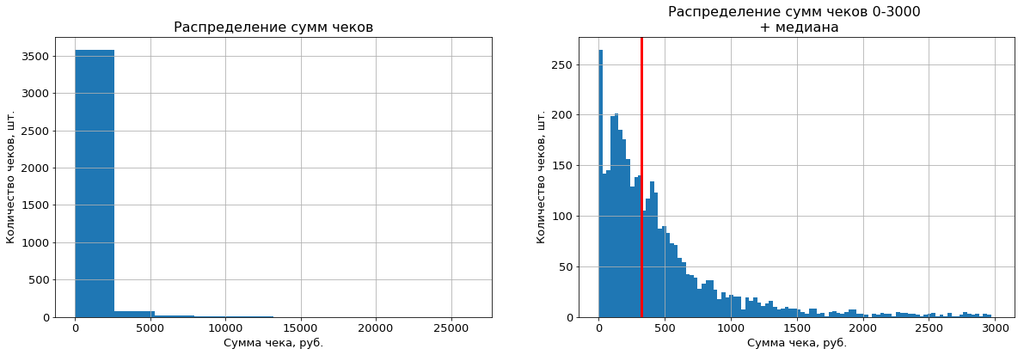

```python
plt.figure(figsize=(20, 6))

ax1 = plt.subplot(1, 2, 1)
ax1 = purchases['total_sum'].hist(bins=10)
ax1.set_title('Распределение сумм чеков', fontsize=16)
ax1.tick_params(labelsize=13)
ax1.set_xlabel('Сумма чека, руб.', fontsize=13)
ax1.set_ylabel('Количество чеков, шт.', fontsize=13)

ax2 = plt.subplot(1, 2, 2)
ax2 = purchases['total_sum'].hist(range=(0, 3000), bins=100)
x2 = purchases['total_sum'].median()
ax2.axvline(x=x2, color='#FF0000', lw=3, linestyle='-')
ax2.set_title('Распределение сумм чеков 0-3000 \n + медиана', fontsize=16)
ax2.tick_params(labelsize=13)
ax2.set_xlabel('Сумма чека, руб.', fontsize=13)
ax2.set_ylabel('Количество чеков, шт.', fontsize=13)

plt.show()
```

#### Анализ товаров.

```python
items = (data.groupby('item_id', as_index=False).agg(in_purchase=('purchase_id', 'nunique'),
                                                     quantities=('quantity', 'sum'),
                                                     customers=('customer_id', 'nunique'),
                                                     total_sum=('total', 'sum')).
             fillna(0).
             sort_values(by='total_sum', ascending=False).
             reset_index(drop=True)
             )
items.head()
```

|  | item_id | in_purchase | quantities | customers | total_sum |
| --- | --- | --- | --- | --- | --- |
| 0 | 22423 | 319 | 3583 | 198 | 45647.42 |
| 1 | 85123A | 486 | 7671 | 309 | 23780.10 |
| 2 | 79321 | 151 | 3448 | 68 | 19826.00 |
| 3 | 21623 | 33 | 2070 | 28 | 19085.40 |
| 4 | POST | 138 | 1426 | 93 | 18523.74 |

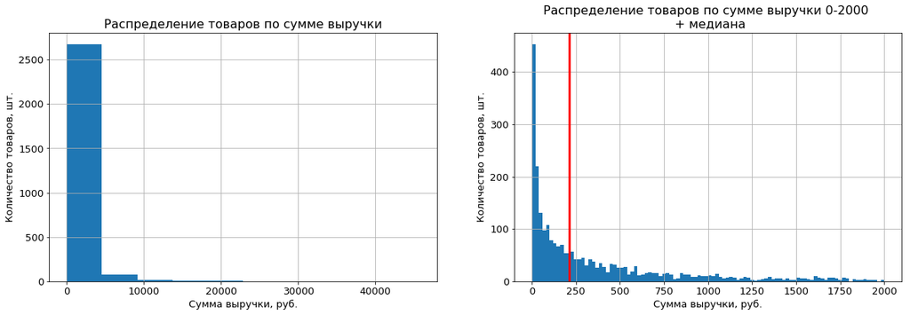

```python
plt.figure(figsize=(20, 6))

ax1 = plt.subplot(1, 2, 1)
ax1 = items['total_sum'].hist(bins=10)
ax1.set_title('Распределение товаров по сумме выручки', fontsize=16)
ax1.tick_params(labelsize=13)
ax1.set_xlabel('Сумма выручки, руб.', fontsize=13)
ax1.set_ylabel('Количество товаров, шт.', fontsize=13)

ax2 = plt.subplot(1, 2, 2)
ax2 = items['total_sum'].hist(range=(0, 2000), bins=100)
x2 = items['total_sum'].median()
ax2.axvline(x=x2, color='#FF0000', lw=3, linestyle='-')
ax2.set_title('Распределение товаров по сумме выручки 0-2000 \n + медиана', fontsize=16)
ax2.tick_params(labelsize=13)
ax2.set_xlabel('Сумма выручки, руб.', fontsize=13)
ax2.set_ylabel('Количество товаров, шт.', fontsize=13)

plt.show()
```